# 수리통계학 지수분포와 포아송분포

- 지수분포와 포아송분포의 관계를 쉽게 나타내보자!

```python
import numpy as np
import matplotlib.pyplot as plt
import pandas as pd
```

`-` intro

```
- 포아송분포와 지수분포가 서로 어떤 관계가 있는지를 파악해보고 쉽게 개념을 설명하고자 한다.
```

# 포아송분포란?

- 시간이 지남에 따라 어떤 특정 사건이 일어나는 발생 횟수의 분포를 의미한다
- 예를 들어 하루 동안 내 핸드폰에 전화가 올 확률을 얼마일까?

`-` 문제해결

- 하루 동안 내 핸드폰에 전화가 2번 이하로 올 확률은?
- 너무 궁금한 나머지 내 전화기록을 뒤져보니 보통 하루에 3건 정도의 통화기록이 남아있다.

`-` 포아송분포의 mgf

- 이를 파이썬으로 구현해보자 $$ f(x) = \frac{exp(-\lambda)\lambda^x}{x!} $$

```python
# 팩토리얼 함수
def fac(n):
    return n * fac(n-1) if n > 1 else 1

# 포아송 분포
x=np.arange(0,10,1)
mean = 3
result = [(np.exp(-mean)*(mean**x[i]))/(fac(x[i])) for i in range(len(x))]
pd.DataFrame(result)
```

|  | 0 |
| --- | --- |
| 0 | 0.049787 |
| 1 | 0.149361 |
| 2 | 0.224042 |
| 3 | 0.224042 |
| 4 | 0.168031 |
| 5 | 0.100819 |
| 6 | 0.050409 |
| 7 | 0.021604 |
| 8 | 0.008102 |
| 9 | 0.002701 |

$$ P(X\le 2) = F(2) $$

```python
print('문제정답 : ',sum(result[0:3]).round(3))
```

```
문제정답 :  0.423
```

- 우리는 문제에 대한 답을 구해내었다.
- 그렇다면 지수분포와는 어떤 관계를 지니고 있는 걸까?

# 지수분포와 포아송분포의 관계

$$ f(x) = \frac{exp(-\lambda )\lambda ^{x}}{x!} $$

- mgf에서 아무것도 일어나지 않을 확률을 나타내면

$$ f(0) = \frac{exp(-\lambda )\lambda ^{0}}{0!} \\ = exp(-\lambda ) $$

- 전체확률에서 위의 확률을 제거하면 단 한번이라도 일어날 사건의 확률이 된다

$$ P(X \le 1 )= 1- exp(-\lambda ) $$

- 이것은 누적분포함수로 나타내면 $$ F(1) = P(X \le 1) \\ $$
- 누적분포함수를 미분 $$ \lambda exp(-\lambda ) $$
- 이런 함수가 나타나고 이는 지수분포와 동일하다
- 지수분포에 평균 3을 넣고 값을 구하면 해당 값은 우리가 포아송분포로 구한 어떤값과 일치하게 된다

```python
(mean*np.exp(-mean)), result[1]
```

```
(0.14936120510359183, 0.14936120510359183)
```

- 즉 포아송분포에서 사건이 단 1번이라도 발생할 확률과 지수분포에서 람다를 포아송분포의 평균 람다로 설정한 값은 같음
- 연속형으로 구간별 확률을 구할 수 있게된다.
- 통화가 단 1번이라도 발생할 확률에 대한 분포를 구해보자

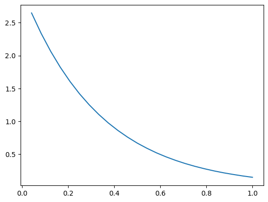

```python
x = np.arange(1/24,1.01,1/24)
mean=3
f = (mean*np.exp(-(mean)*x)).round(3)

plt.plot(x,f)
```

- 평균 하루 3번의 전화가 오는 사람에 대해서 전화가 하루 한번이라도 올 확률은 아래와 같다

```python
1-np.exp(-mean)
```

```
0.950212931632136
```